# Twitter Analytics - Arctic Data Center

## Arctic Data Center Twitter Metrics

This report contains information about the Arctic Data Center’s Twitter account, @ArcticDataCtr, and how effective it is at engaging a wider audience of Arctic researchers, students, and other data organizations.

### How has the Arctic Data Center’s Twitter account increased its reach over time?

The Arctic Data Center account currently has 1113 followers.

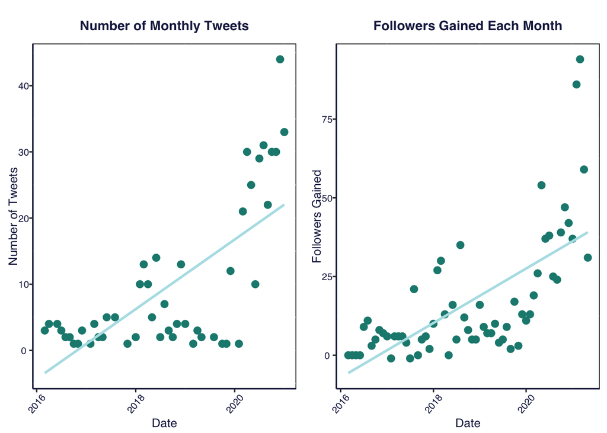

These next two graphs dig into the metrics associated with each Tweet. Every organic Tweet has a certain number of engagements (that is, the number of times users interact with the Tweet) and impressions (the number of times users are served that Tweet in their timeline). The data presented are normalized on a per Tweet basis because of course there will be more total engagements and impressions as the quantity of Tweets increases.

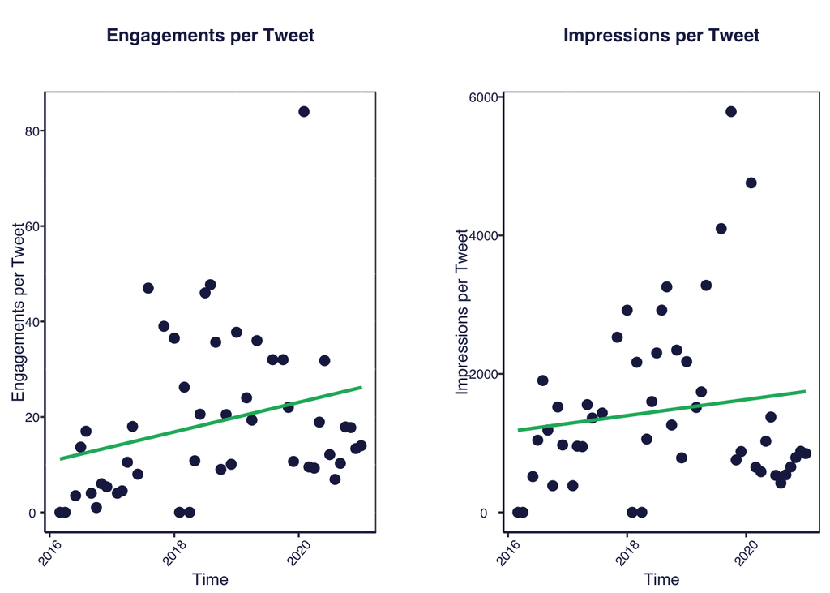

| Tweet | Timestamp | Engagements |
| --- | --- | --- |
| For #SharingSciFri, we’re highlighting a pioneer in #Arctic exploration: Matthew Henson, who was the first Black man to reach the #NorthPole! Read more about his legacy and his role in exploration fro… | 2020-06-05 14:28:02 | 170 |
| New feature alert! #Arctic #researchers can now create a portal with @arcticdatactr to see #data from across the #catalog all in one place. Each #portal can be branded with logos and colors and has a … | 2020-05-05 16:30:23 | 148 |
| Know your #Arctic #vocabulary! Aufeis is a sheet-like mass of layered ice that forms from successive flows of ground water during freezing temperatures. Alexander Huryn et al wrote a #newpaper so you … | 2021-01-08 15:28:02 | 140 |
| The @arcticdatactr is looking forward to the #datahelpdesk at #AGU20! Ask us - and all the other experts, led by @ESIPfed - any and all of your #data questions 7-11 and 14-16 December as part of @theA… | 2020-11-30 17:28:09 | 127 |
| Fittingly, the last day of our #Arctic #datascience training is on #DATAPALOOZA day! We’ve enjoyed learning #dataviz #rstats #github & more #data skills and sharing #opendata sources & best #datamanag… | 2018-08-17 18:43:07 | 116 |

| Tweet | Timestamp | Impressions |
| --- | --- | --- |
| Headed to @POLAR_2018? Join us at our 3 FREE Data Management Workshops during the Open Science Conference! We look forward to meeting you & working to help address your #arctic data needs. From planni… | 2018-06-04 17:00:01 | 9931 |
| Fittingly, the last day of our #Arctic #datascience training is on #DATAPALOOZA day! We’ve enjoyed learning #dataviz #rstats #github & more #data skills and sharing #opendata sources & best #datamanag… | 2018-08-17 18:43:07 | 7421 |
| Calling #Arctic researchers - Do your research data management skills need refreshing? Want to work in a more open, efficient and reproducible way? Apply by August 15th to join our funded Data Science… | 2019-08-01 17:46:23 | 6295 |
| The @arcticdatactr is looking forward to the #datahelpdesk at #AGU20! Ask us - and all the other experts, led by @ESIPfed - any and all of your #data questions 7-11 and 14-16 December as part of @theA… | 2020-11-30 17:28:09 | 6075 |
| Know your #Arctic #vocabulary! Aufeis is a sheet-like mass of layered ice that forms from successive flows of ground water during freezing temperatures. Alexander Huryn et al wrote a #newpaper so you … | 2021-01-08 15:28:02 | 5871 |

The number of engagements includes all actions that a user could take with a Tweet, including Retweeting, clicking anywhere on the Tweet, or favoriting the Tweet. To dig further into those engagements, the following graphs show the number of likes and retweets on a per Tweet basis.

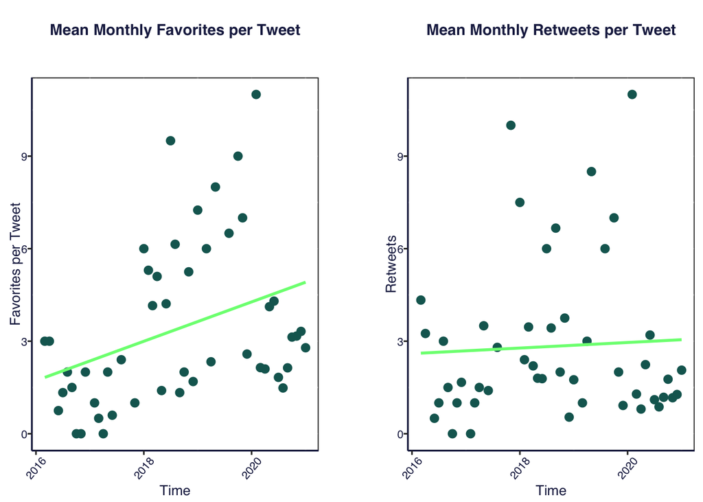

| Tweet | Timestamp | Likes |
| --- | --- | --- |
| New feature alert! #Arctic #researchers can now create a portal with @arcticdatactr to see #data from across the #catalog all in one place. Each #portal can be branded with logos and colors and has a … | 2020-05-05 16:30:23 | 28 |
| For #SharingSciFri, we’re highlighting a pioneer in #Arctic exploration: Matthew Henson, who was the first Black man to reach the #NorthPole! Read more about his legacy and his role in exploration fro… | 2020-06-05 14:28:02 | 22 |
| Anxiously awaiting the next #dataset highlight? Now it’s live! We’re excited to highlight @rosem36 & her team researching DOC along the Kuparuk River. Learn about the importance of their #data & disco… | 2018-04-10 19:11:36 | 20 |
| Reaching out to the biodiversity community with repository management best practices and lessons learned from the Arctic Data Center #digidata @i_steves https://t.co/b9djUYuxiP | 2018-06-04 22:46:53 | 19 |
| Headed to @POLAR_2018? Join us at our 3 FREE Data Management Workshops during the Open Science Conference! We look forward to meeting you & working to help address your #arctic data needs. From planni… | 2018-06-04 17:00:01 | 13 |

| Tweet | Timestamp | Retweets |
| --- | --- | --- |
| Calling all #Arctic researchers: Want to improve your #data management skills & learn ways to implement #DataScience tools in your work? Join us & your arctic colleagues @nceas in August for our 2018 … | 2018-03-15 17:27:58 | 16 |
| We’re looking for input from educators who teach or want to teach #Arctic science! #STEMeducation #AcademicChatter #edchat To what extent do you need Arctic #data-focused educational materials for you… | 2020-05-26 22:05:13 | 16 |
| We’re hiring! Support the @arcticdatactr and other @nceas projects in building community, supporting Arctic research and promoting open science and data reuse. Community Engagement and Outreach Coordi… | 2019-05-09 18:24:57 | 15 |
| For #SharingSciFri, we’re highlighting a pioneer in #Arctic exploration: Matthew Henson, who was the first Black man to reach the #NorthPole! Read more about his legacy and his role in exploration fro… | 2020-06-05 14:28:02 | 14 |
| #Job announcement - The Arctic Data Center and @nceas are looking for Data Fellows! UCSB is an EOE, including disability/vets. https://t.co/CKVhTxldUr | 2020-02-20 23:29:28 | 11 |

#### Distribution of replies, retweets, and organic tweets

Analyzing the ratio of replies, retweets and organic tweets can tell you a great deal about the type of account you’re analysing. No one likes a Twitter account that exclusively retweets for instance, without any individual content. Finding a good ratio of replies, retweets and organic tweets is therefore a key metric to monitor if one wishes to improve the performance of an account.

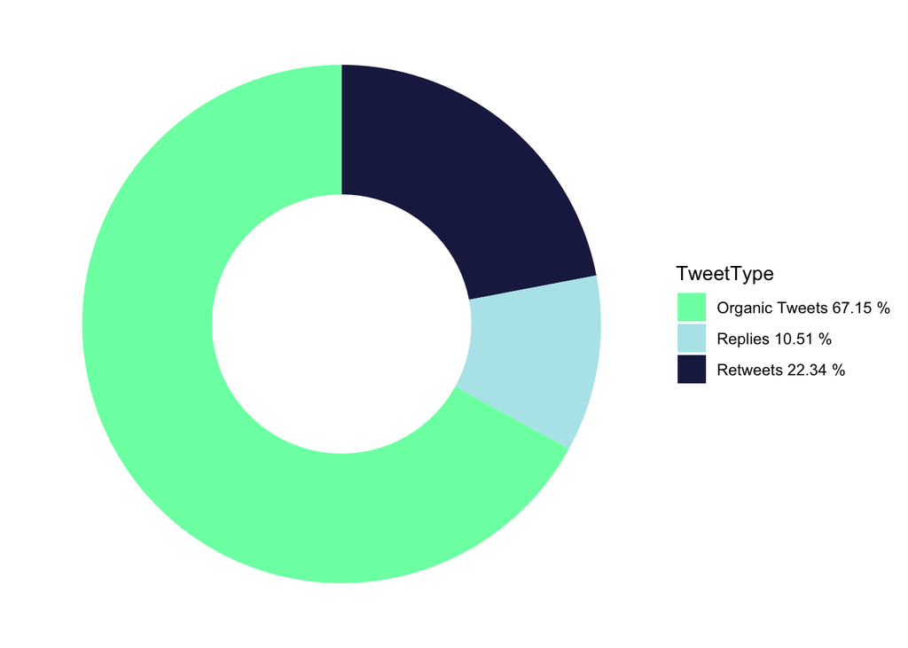

### Engagement with the larger Arctic Research / Policy Community

One way to understand how impactful our Tweets are is by looking at number of times that influential Twitter accounts that are mentioning @ArcticDataCtr (1113 followers) in their Tweets. Influential accounts in the Arctic research space: ArcticResearch (4012 followers), ESA_org (40742 followers), IARC_Alaska (2668 followers), IARPCCollab (946 followers), NSIDC (16709 followers), Polar_Research (10090 followers), PolarImpact (3235 followers), PopePolar (5721 followers), PridePolar (4129 followers), theAGU (NA followers), Toolik (923 followers), UArctic (7847 followers), and US_APECS (834 followers).

Influential accounts in the data repository or open science space: DataONEorg (3788 followers), EDIgotdata (582 followers), ESIPfed (2867 followers), MakeDataCount (1012 followers), NCEAS (9553 followers), NEON_sci (6861 followers), rOpenSci (32175 followers), and USLTER (5388 followers).

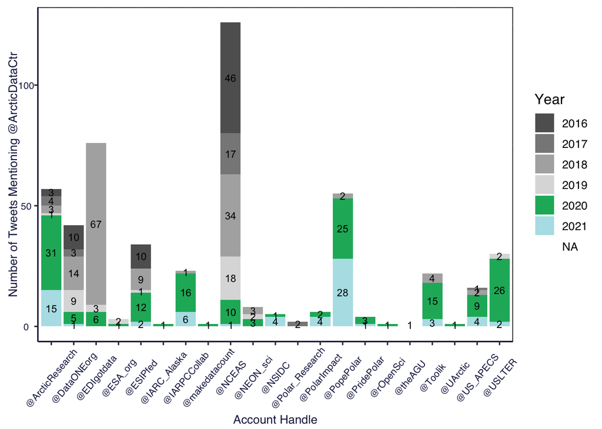

This graph illustrate places where we should increase our reach - focus on getting these influential accounts to interact with our content via retweets, replies, and tags within tweets.

### When is the best day and time to post tweets?

Obviously we want to make sure we’re tweeting at the right times, so that our community will see and interact with those tweets. Only organic tweets are included in this analysis because engagements and impressions are not calculated the same way for retweets or replies.

#### Does it matter what time the tweets are sent out to the community?

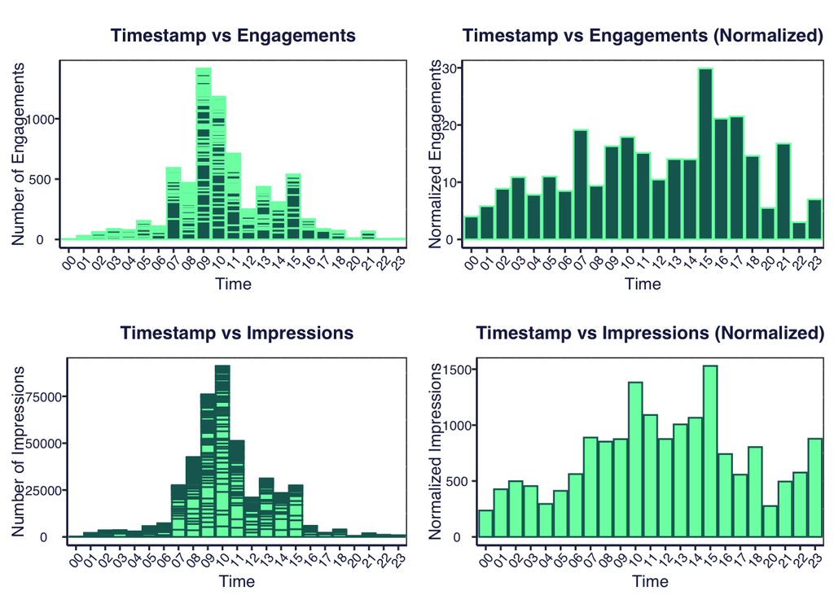

#### What about the day of the week?

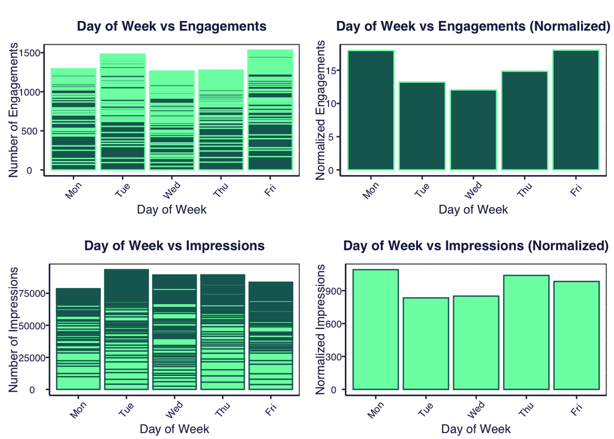

Looking at the normalized data (that is, accounting for the number of tweets that have been sent out in each hour bucket), it appears that the top two days of the week to tweet for the most engagement are Fri and Mon. The top two days of the week to tweet for the most impressions are Mon and Thu - with Monday overlapping between the two. Previous to this analysis, we were not generating organic content on Mondays - that was a day largely reserved for retweeting (with comment, so it counts in the organic Tweet analysis) content from other accounts. Moving forward, we will Tweet more original content on Mondays, to see if this is an artifact of Retweeting or if Monday is truly the day that our community is most active on Twitter.

### Should we include photos with Tweets or not?

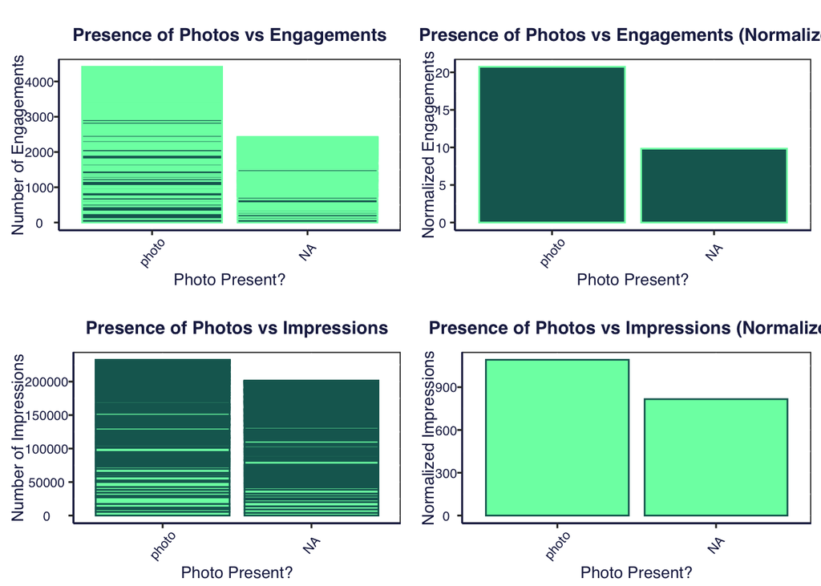

### Twitter as a gateway to arcticdata.io

With the power of Google Analytics, we can see how users of arcticdata.io are interacting with the site - where they arrived from and what they do when they’re there.

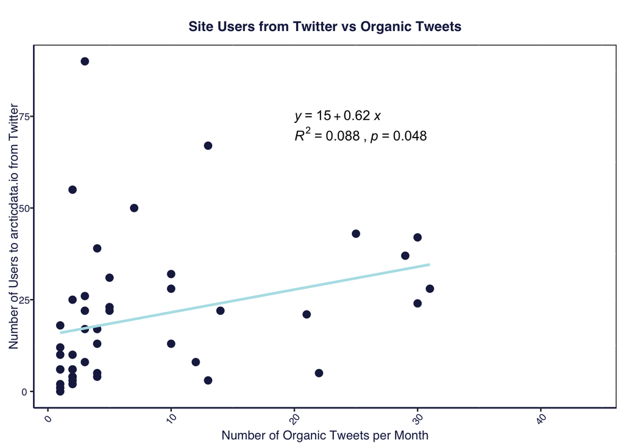

We can see how many users are arriving to the site directly from a Twitter link. This analysis shows that for every organic Tweet that we produce, we add 0.62 unique visitors specifically from Twitter to our site. That may not seem like much, but it’s a metric that we can now track and keep striving to increase.

Plus, many of the tweets that we send out link out to other websites or information - not all of our Tweets are intended to bring folks back to arcticdata.io. That lead us to investigate the total number of users on the site correlated to the number of organic Tweets.

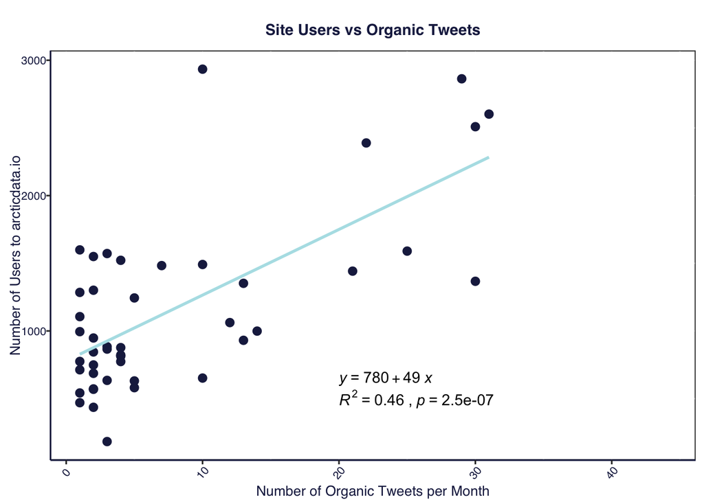

When total users of the Arctic Data Center are correlated to the number of organic Tweets per month, we see a much more impactful picture. An active Twitter presence keeps the Arctic Data Center top of mind for researchers and others in the data sharing community, and that seems to translate into increased site visits. This analysis shows that for every organic Tweet that we produce, we add 48.52 unique visitors to our site. Of course, this is less of a direct link, but it’s encouraging to see that positive correlation.

### Data Collection - Summary

Data was collected manually on the first of the month from https://analytics.twitter.com/user/arcticdatactr/home. In addition to parameters not necessary to this analysis, this summary file contains:

- month: month of Tweet information
- year: year of Tweet information
- tweets: number of Tweets that month
- profile-visits: number of times users visited the @ArcticDataCtr profile page
- new-followers: number of new followers gained (gross new followers; does not account for followers lost)
- tweet-impressions: number of times users are served @ArcticDataCtr tweets in timeline, search results, or from the profile
- mentions: number of times @ArcticDataCtr was mentioned in tweets
- number-followers: number of followers, manually copied from https://twitter.com/arcticdatactr.
  - Number of followers is the only piece of data in this file that is only available from Twitter at the time you access the site i.e. it is not made available with the rest of the data in this dataset. Thus, there are NAs for dates prior to the time I started to collect this data or for dates before I realized this data was ephemeral.

### Data Collection - Monthly Tweets

Data was scraped using the R package rtweet. In addition to parameters not necessary to this analysis, this data contains the following parameters:

- status_id: the identifier for the Tweet, which can be used to find the permanent URL
- created_at: the time the Tweet was sent (GMT)
- text: the text (content) of the Tweet
- display_text_width: how many characters are in the Tweet
- reply_to_status_id: whether the Tweet was a reply
- reply_to_screen_name: who the Tweet was a reply to
- is_retweet: whether the Tweet was a retweet
- favorite_count: number of likes
- retweet_count: number of retweets
- hashtags: what hashtags were used in the Tweet content
- media_type: what type of media was attached to the Tweet
- mentions_screen_name: what other Twitter accounts were mentioned (@) in the Tweet

Additionally, Tweet-level data was also downloaded from https://analytics.twitter.com/user/arcticdatactr/home, and in addition to parameters not necessary to this analysis, this data contains the following additional parameters:

- Tweet.id: the identifier for the Tweet, which can be used to find the permanent URL
- impressions: number of times users are served the tweet in timeline, search results, or from the @ArcticDataCtr profile
- engagements: total number of times a user interacted with a Tweet. Clicks anywhere on the Tweet, including Retweets, replies, follows, likes, links, cards, hashtags, embedded media, username, profile photo, or Tweet expansion
- engagement.rate: number of engagements divided by impressions
- replies: number of replies that Tweet generated
- user.profile.clicks: number of times a user clicked on the @ArcticDataCtr profile from that particular tweet
- URL.clicks: number of times that URL within the tweet was clicked
- hashtag.clicks: number of times any of your hashtags were clicked from that tweet
- detail.expands: number of times users clicked ‘see more’ on your tweet
- permalink.clicks: clicks on the Tweet permalink
- follows: times a user followed you directly from the Tweet
- media.views: number of times media attached to the Tweet is viewed
- media.engagements: an interaction on a tweet that has a piece of media (photo, vine, other video, etc) in it

Data scraped from rtweet and downloaded from the Twitter metrics page were joined based on the Tweet id / status_id variable.